# Laboratory of Customer and Business Analytics - Smartphones Report

Dall’Asen Nicola (211662) - Debeni Andrea (211664) - Zorzoni Riccardo (220500)

12/21/2020

# Introduction

The aim of this study is to provide an insight on the most important features that customer take into consideration when they choose a new smartphone, in order to provide market segments and analyze customers’ tastes. The study has been conducted through the use of a choice-based conjoint analysis on data collected through an online survey thanks to the statistical tool of Multinomial Logistic Regression and Bootstrap prediction.

## Expectations and common sense

Before starting the analysis, we had some expectations based on our personal experiences as scientific students and tech enthusiasts. The first concern of an average user is about the price: how much he can afford at the moment of the purchase is, inevitably, a major limit to all the other considerations on the smartphone’s features, and consequently the quality/price ratio should always be maximized. This ratio is clearly dependent on different features, and it changes from user to user.

Users could be grouped into categories, and even if the precise identification of these categories is not the aim of this research, their experience-driven identification helped us in shaping a common sense in what we may expect from the results of the analysis. For example, a user not used to taking pictures or sharing them on social networks would be more inclined to buy a smartphone that works best on its everyday usage, while an Instagram addicted teenager would prefer the so-called “camera-phone”. Considering that the average age of the respondents should be low (university students, mostly), we were expecting slight advantages in features like daily usage and camera, given the high amount of time spent with the smartphone by young people and their propensity to use social media and share pictures and videos on them. In our opinion, operating systems shouldn’t affect the results much, especially because it’s actually difficult to have a full understanding of all the aspects related to different OS from a simple form. Moreover, the small number of devices released by Apple during the year could affect negatively on its result given its small appearance ratio over the totality of profiles.

## Data collection

In order to collect the data needed for our analysis we designed a survey where respondents were asked to choose the smartphone profile that best suited their real-life choices. How the profiles were generated is explained further in this section. Each person answering the survey was asked to answer 13 questions and each question was composed by 3 different smartphone profiles.

Every profile is composed by several features that commonly describe such product, i.e. price, RAM and storage, quality of the display, daily usage (if the product is able to carry out daily tasks in an optimal way), quality of the camera and battery. Given the extreme heterogeneity of evaluation of such features, a known and established source was taken as ground truth for these values [2], this source provides reviews for different smartphones and a numeric summary of the features taken into account. To avoid having respondents deal with many numerical values which provide little to none meaning to the average user, the features, except price and RAM/storage, were grouped into three categories, i.e. “low”, “medium” and “high” and the conversion tables are provided below. Prices were rounded to the closest hundredth, while RAM/storage was grouped into the three most common configurations for recent smartphones, “4/64 GB” for low-end devices, “8/128” for medium-end and “12/256” for high-end.

We decided to use only 2020’s smartphones, because the price may vary due to the rapid changes and evolution of the hardware. In order to have a wide range of profiles, we selected 39 smartphones of the last year. Then we put the price averaging the most popular e-commerce site and physical market. Almost all our profiles are with Android operating system, due to the poor range of Apple products with respect to the other firms. After that we converted the features using the table below.

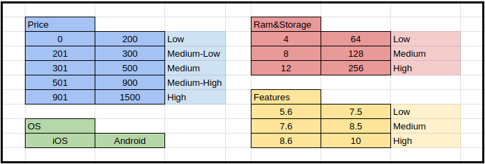

Conversion table

At this point, we were able to create the final table from which we started to build the survey. The table is shown below, and it is possible to see the original value and the transformed one.

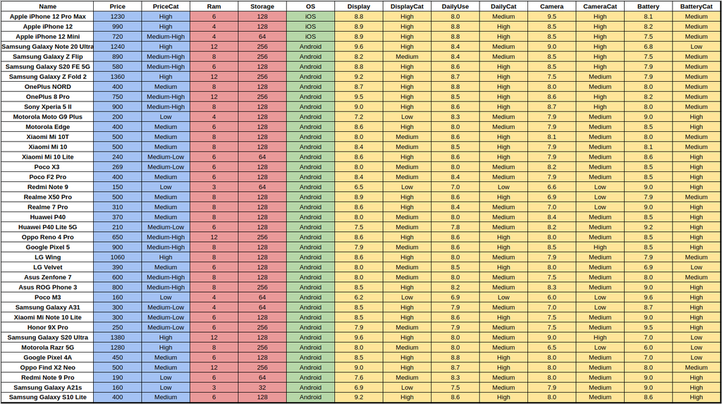

Smartphone dataset

We built the survey randomly shuffling the 39 profiles into 13 choice questions. The survey was done by 109 respondents using Google Form, and all the results were stored in Google Sheet. Therefore, these data have been reorganized to show the chosen profile at each question. After that, we prepared the data for the future analysis, transposing the table and interpolating it with all the profiles.

At this point, we had a table with all the respondents’ choice, and all the features for each profile.

### Method used

To avoid generating every possible smartphone configuration (considering every hundredth of the price as one category it would have led to more than 5000 different profiles, most of which are unrealistic) we considered a subset of smartphone released on the market during 2020 which have the most different characteristics, similarly to the fractional factorial design principle [1], and after applying the transformations listed above we used them as our products’ profiles for the survey. The survey was presented to an heterogeneous group of people with the aim to provide a representative sample and capture the most people’s behavior. It was presented to a total of N=109 people through Google Forms.

### Data preprocessing

Google Forms collects respondents’ answers in a format which is not suitable for our analysis (MNL through mlogit R package), it provides only the content of the answer the user chose and therefore, in order to construct the dataset in a suitable way, we took several preprocessing steps involving several technologies. As the first step we worked on spreadsheets to transform the content of the answer into the ID of the smartphone profile, which we have kept in a separate sheet. With this information we could easily retrieve the whole chosen profile but a problem arose, because there was no easy manner to include, for every respondent for every question, the options we had not chosen. For this task we involved the use of Python and pandas dataframes [3], which provided us with SQL-like join operator to construct respondents’ profiles (the code is available in the dataTransform.ipynb Python notebook). The resulting data are in a long format which provide many benefits, first of all many advanced statistical libraries prefer this data format for computing and graphing (e.g. ggplot, lm or t.test) and secondly it provides a conceptual clarity and easiness to summary data, which cannot be achieved by wide data because every observation is a mix of a unit of analysis and and a value-holding variable. [4] These resulting data were then imported in R and before starting the actual analysis a last step was required, converting strings to factors in order to obtain ordinal categorical variables.

# Data Analysis

```r
library(mlogit)
library(parallel)
library(MASS)
```

### Data loading and cleaning

```r
smartphones.df <- read.csv("final.csv", sep=",")
names(smartphones.df) <- c("X", "smart.id", "quest.id", "smart.name", "profile", "price", "ram.storage", "os", "display", "dailyuse", "camera", "battery", "resp.id", "choice")
# Filter needed columns
to_keep_cols <- c("resp.id", "quest.id", "profile", "price", "ram.storage", "os", "display", "dailyuse", "camera", "battery", "choice")
smartphones.df <- smartphones.df[,to_keep_cols]
# mlogit requires every question to have a different ID
smartphones.df$quest.id <- rep(1:1417, each= 3)

# recode some variables
smartphones.df$price <- as.factor(smartphones.df$price)
smartphones.df$ram.storage <- factor(smartphones.df$ram.storage, levels = c("4/64", "8/128", "12/256"))
smartphones.df$os <- factor(smartphones.df$os)
smartphones.df$display <- factor(smartphones.df$display, levels = c("Low", "Medium", "High"))
smartphones.df$dailyuse <- factor(smartphones.df$dailyuse, levels = c("Low", "Medium", "High"))
smartphones.df$camera <- factor(smartphones.df$camera, levels = c("Low", "Medium", "High"))
smartphones.df$battery <- factor(smartphones.df$battery, levels = c("Low", "Medium", "High"))
smartphones.df$profile <- as.factor(smartphones.df$profile)
```

## Fixed MNL

```r
# convert data to the format accepted by mlogit
smartphones.mlogit <- dfidx(smartphones.df, idx = list(c("quest.id", "resp.id"), "profile"), drop.index=F,
                        levels=c("1", "2", "3"))
```

```r
# Fit the mlogit model to the data
fmnl.intercept <- mlogit(choice ~ price + ram.storage + os + display +
               dailyuse + camera + battery, data = smartphones.mlogit)
summary(fmnl.intercept)
```

```r
# Fit the model without intercept parameters
fmnl.no.intercept <- mlogit(choice ~ price + ram.storage + os + display +
               dailyuse + camera + battery | -1, data = smartphones.mlogit)
summary(fmnl.no.intercept)
```

```
##
## Call:
## mlogit(formula = choice ~ price + ram.storage + os + display +
##     dailyuse + camera + battery | -1, data = smartphones.mlogit,
##     method = "nr")
##
## Frequencies of alternatives:choice
##       1       2       3
## 0.37756 0.36062 0.26182
##
## nr method
## 7 iterations, 0h:0m:0s
## g'(-H)^-1g = 0.000111
## successive function values within tolerance limits
##
## Coefficients :
##                    Estimate Std. Error z-value  Pr(>|z|)
## price300           0.033959   0.345233  0.0984 0.9216430
## price400          -0.800987   0.259458 -3.0872 0.0020208 **
## price500          -1.815104   0.469111 -3.8692 0.0001092 ***
## price600          -2.465258   0.518642 -4.7533 2.001e-06 ***
## price700          -2.476787   0.539216 -4.5933 4.363e-06 ***
## price800          -3.194181   0.574652 -5.5585 2.722e-08 ***
## price900          -1.976708   0.650361 -3.0394 0.0023705 **
## price1000         -1.320500   1.035428 -1.2753 0.2021964
## price1100         -5.904984   1.032205 -5.7207 1.061e-08 ***
## price1200          0.964339   2.070259  0.4658 0.6413544
## price1300          0.266350   1.429923  0.1863 0.8522339
## price1400         -0.674988   1.083971 -0.6227 0.5334822
## ram.storage8/128   0.993775   0.421536  2.3575 0.0183979 *
## ram.storage12/256  0.998973   0.538649  1.8546 0.0636548 .
## osiOS             -0.097523   0.570018 -0.1711 0.8641550
## displayMedium      1.503510   0.316963  4.7435 2.101e-06 ***
## displayHigh        2.439940   0.390641  6.2460 4.211e-10 ***
## dailyuseMedium    -0.991577   0.620256 -1.5987 0.1098968
## dailyuseHigh      -0.776852   0.859081 -0.9043 0.3658454
## cameraMedium       2.134449   0.526337  4.0553 5.007e-05 ***
## cameraHigh         1.931570   0.675558  2.8592 0.0042468 **
## batteryMedium      2.486701   0.378885  6.5632 5.266e-11 ***
## batteryHigh        2.488928   0.390073  6.3807 1.763e-10 ***
## ---
## Signif. codes:  0 '***' 0.001 '**' 0.01 '*' 0.05 '.' 0.1 ' ' 1
##
## Log-Likelihood: -1002
```

```r
# Test the restriction on the intercepts by comparing the two models through a likelihood ratio test
lrtest(fmnl.no.intercept, fmnl.intercept)
```

```
## Likelihood ratio test
##
## Model 1: choice ~ price + ram.storage + os + display + dailyuse + camera +
##     battery | -1
## Model 2: choice ~ price + ram.storage + os + display + dailyuse + camera +
##     battery
##   #Df  LogLik Df Chisq Pr(>Chisq)
## 1  23 -1002.0
## 2  25 -1000.8  2  2.29     0.3182
```

```r
# Fit the model without intercept parameters and with price as a quantitative variable
fmnl.no.intercept.quantitative <- mlogit(choice ~ as.numeric(as.character(price)) + ram.storage + os + display + dailyuse + camera + battery | -1, data = smartphones.mlogit)
summary(fmnl.no.intercept.quantitative)
```

```r
lrtest(fmnl.no.intercept.quantitative, fmnl.no.intercept)
```

```
## Likelihood ratio test
##
## Model 1: choice ~ as.numeric(as.character(price)) + ram.storage + os +
##     display + dailyuse + camera + battery | -1
## Model 2: choice ~ price + ram.storage + os + display + dailyuse + camera +
##     battery | -1
##   #Df  LogLik Df Chisq Pr(>Chisq)
## 1  12 -1031.3
## 2  23 -1002.0 11 58.73  1.594e-08 ***
## ---
## Signif. codes:  0 '***' 0.001 '**' 0.01 '*' 0.05 '.' 0.1 ' ' 1
```

With the last model, having price as a quantitative variable, we can compute the willingness to pay for some features

```r
#coef(m3)["ram.storage8/128"]/(coef(m3)["as.numeric(as.character(price))"])
#coef(fmnl.no.intercept.quantitative)["ram.storage12/256"]/(coef(fmnl.no.intercept.quantitative)["as.numeric(as.character(price))"])
coef(fmnl.no.intercept.quantitative)["osiOS"]/(coef(fmnl.no.intercept.quantitative)["as.numeric(as.character(price))"])
```

```
##     osiOS
## -215.4221
```

```r
#coef(m3)["displayMedium"]/(coef(m3)["as.numeric(as.character(price))"])
#coef(fmnl.no.intercept.quantitative)["displayHigh"]/(coef(fmnl.no.intercept.quantitative)["as.numeric(as.character(price))"])
#coef(m3)["dailyuseMedium"]/(coef(m3)["as.numeric(as.character(price))"])
#coef(fmnl.no.intercept.quantitative)["dailyuseHigh"]/(coef(fmnl.no.intercept.quantitative)["as.numeric(as.character(price))"])
#coef(m3)["cameraMedium"]/(coef(m3)["as.numeric(as.character(price))"])
coef(fmnl.no.intercept.quantitative)["cameraHigh"]/(coef(fmnl.no.intercept.quantitative)["as.numeric(as.character(price))"])
```

```
## cameraHigh
##  -477.1271
```

```r
#coef(m3)["batteryMedium"]/(coef(m3)["as.numeric(as.character(price))"])
coef(fmnl.no.intercept.quantitative)["batteryHigh"]/(coef(fmnl.no.intercept.quantitative)["as.numeric(as.character(price))"])
```

```
## batteryHigh
##   -620.4764
```

The willingness to pay has also been computed: results show that an average user is willing to pay up to 215€ more to purchase a smartphone with an iOS operating system than its counterpart with an Android operating system. Camera and battery are also extremely important, since it is shown that the willingness to pay for a high level of both features is about 475€ and 620€, respectively.

Instead of keeping this amount of levels for the price variable, we group it into the 5 categories explained at the beginning

```r
tmp.df <- smartphones.df
tmp.df$price <- as.numeric(as.character(tmp.df$price))
tmp.df$price <- cut(tmp.df$price, c(-Inf, 200, 300, 500, 900, Inf), c("L","ML", "M", "MH", "H"))
tmp.df$price <- factor(tmp.df$price, levels = c("L","ML", "M", "MH", "H"))

updated.smartphones.mlogit <- dfidx(tmp.df, idx = list(c("quest.id", "resp.id"), "profile"), drop.index=F,
                            levels=c("1", "2", "3"))
```

We then fit a new model without intercept on these new data

```r
fmnl.no.intercept.ranges <- mlogit(choice ~ price + ram.storage + os + display +
               dailyuse + camera + battery | -1, data = updated.smartphones.mlogit)
summary(fmnl.no.intercept.ranges)
```

```
##
## Call:
## mlogit(formula = choice ~ price + ram.storage + os + display +
##     dailyuse + camera + battery | -1, data = updated.smartphones.mlogit,
##     method = "nr")
##
## Frequencies of alternatives:choice
##       1       2       3
## 0.37756 0.36062 0.26182
##
## nr method
## 6 iterations, 0h:0m:0s
## g'(-H)^-1g = 0.00085
## successive function values within tolerance limits
##
## Coefficients :
##                    Estimate Std. Error  z-value  Pr(>|z|)
## priceML           -0.369143   0.206554  -1.7872  0.073912 .
## priceM            -0.484634   0.202802  -2.3897  0.016862 *
## priceMH           -2.566181   0.258415  -9.9305 < 2.2e-16 ***
## priceH            -3.229015   0.299318 -10.7879 < 2.2e-16 ***
## ram.storage8/128   1.030107   0.246655   4.1763 2.963e-05 ***
## ram.storage12/256  1.432640   0.263083   5.4456 5.163e-08 ***
## osiOS              0.830821   0.254638   3.2628  0.001103 **
## displayMedium      1.722321   0.316620   5.4397 5.337e-08 ***
## displayHigh        2.449276   0.348394   7.0302 2.063e-12 ***
## dailyuseMedium    -0.528797   0.477198  -1.1081  0.267806
## dailyuseHigh      -0.063494   0.540505  -0.1175  0.906486
## cameraMedium       1.267772   0.206387   6.1427 8.113e-10 ***
## cameraHigh         2.308265   0.287363   8.0326 8.882e-16 ***
## batteryMedium      1.649291   0.251506   6.5577 5.466e-11 ***
## batteryHigh        2.885698   0.265160  10.8829 < 2.2e-16 ***
## ---
## Signif. codes:  0 '***' 0.001 '**' 0.01 '*' 0.05 '.' 0.1 ' ' 1
##
## Log-Likelihood: -1022.4
```

```r
attributes <- list(ram.storage=names(table(updated.smartphones.mlogit$ram.storage)),
               os=names(table(updated.smartphones.mlogit$os)),
               display=names(table(updated.smartphones.mlogit$display)),
               dailyuse=names(table(updated.smartphones.mlogit$dailyuse)),
               camera=names(table(updated.smartphones.mlogit$camera)),
               battery=names(table(updated.smartphones.mlogit$battery)),
               price=names(table(updated.smartphones.mlogit$price)))
all.designs <- expand.grid(attributes)
```

We then choose a reasonable amount of profiles for every price range and determine the preference shares separately, the “best” profiles for every category are then compared

```r
all.designs.low <- all.designs[all.designs$price=="L" & all.designs$os=="Android" & all.designs$ram.storage=="4/64",]
row.names(all.designs.low) <- NULL
new.data.low <- all.designs.low[c(67, 55, 68, 59, 32, 40, 31, 38, 41, 14, 23),]

all.designs.mlow <- all.designs[all.designs$price=="ML" & all.designs$os=="Android" & all.designs$ram.storage!="12/256",]
row.names(all.designs.mlow) <- NULL
new.data.medium.low <- all.designs.mlow[c(143, 136, 119, 144, 132, 120, 88, 47, 48, 134, 83, 122, 11, 94),]

all.designs.medium <- all.designs[all.designs$price=="M" & all.designs$os=="Android" & all.designs$ram.storage=="8/128",]
row.names(all.designs.medium) <- NULL
new.data.medium <- all.designs.medium[c(45, 69, 44, 68, 36, 60, 17, 18, 72),]

all.designs.mhigh <- all.designs[all.designs$price=="MH",]
row.names(all.designs.mhigh) <- NULL
new.data.medium.high <- all.designs.mhigh[c(319, 322, 242, 245, 302, 305, 249, 252, 320, 476, 297, 321, 429, 411),]

all.designs.high <- all.designs[all.designs$price=="H" & all.designs$ram.storage!="4/64",]
row.names(all.designs.high) <- NULL
new.data.high <- all.designs.high[c(202, 204, 213, 215, 94, 96, 178, 165, 18, 95, 20, 92, 90, 173, 175),]
```

The best for each category are then taken into account for the last preference share prediction

```r
new.data <- all.designs[c(403, 223, 878, 914, 1400, 1382, 1887, 1779, 1763, 2267, 2250, 2264),]
predict.mnl(fmnl.no.intercept.ranges, new.data)
```

```
##           share ram.storage      os display dailyuse camera battery price
## 403  0.03529125        4/64 Android  Medium   Medium Medium    High     L
## 223  0.01739224        4/64 Android  Medium      Low Medium  Medium     L
## 878  0.23993098       8/128 Android    High      Low Medium    High    ML
## 914  0.22517030       8/128 Android    High     High Medium    High    ML
## 1400 0.20061077       8/128 Android    High     High Medium    High     M
## 1382 0.12597255       8/128 Android    High   Medium Medium    High     M
## 1887 0.03742550      12/256 Android    High     High Medium    High    MH
## 1779 0.03076685      12/256 Android    High     High   High  Medium    MH
## 1763 0.02964888       8/128     iOS    High   Medium   High  Medium    MH
## 2267 0.02433444       8/128     iOS    High     High   High  Medium     H
## 2250 0.02285392      12/256     iOS    High   Medium   High  Medium     H
## 2264 0.01060230       8/128 Android    High     High   High  Medium     H
```

To have more statistical-relevant results let’s calculate confidence intervals for the shares

```r
BootCI.predict.mnl(fmnl.no.intercept.ranges, new.data)
```

```
##           share        2.5%      97.5% ram.storage      os display dailyuse
## 403  0.03529125 0.017582767 0.05367411        4/64 Android  Medium   Medium
## 223  0.01739224 0.006539716 0.03687912        4/64 Android  Medium      Low
## 878  0.23993098 0.095447574 0.49445465       8/128 Android    High      Low
## 914  0.22517030 0.141545438 0.29905502       8/128 Android    High     High
## 1400 0.20061077 0.110768604 0.27488096       8/128 Android    High     High
## 1382 0.12597255 0.080763904 0.16322201       8/128 Android    High   Medium
## 1887 0.03742550 0.017187893 0.06238417      12/256 Android    High     High
## 1779 0.03076685 0.016786211 0.04376160      12/256 Android    High     High
## 1763 0.02964888 0.014705493 0.05274277       8/128     iOS    High   Medium
## 2267 0.02433444 0.012269837 0.03591775       8/128     iOS    High     High
## 2250 0.02285392 0.010074103 0.03811743      12/256     iOS    High   Medium
## 2264 0.01060230 0.005233188 0.01713784       8/128 Android    High     High
##      camera battery price
## 403  Medium    High     L
## 223  Medium  Medium     L
## 878  Medium    High    ML
## 914  Medium    High    ML
## 1400 Medium    High     M
## 1382 Medium    High     M
## 1887 Medium    High    MH
## 1779   High  Medium    MH
## 1763   High  Medium    MH
## 2267   High  Medium     H
## 2250   High  Medium     H
## 2264   High  Medium     H
```

By predicting the mnl for this last model, we can find a preference for smartphone with Medium-Low or Medium price range, with an Android operating system and 8/128GB RAM/Storage values, a high level of battery and display, a medium level of camera features and variable level of daily use parameters.

### Calculate and plot sensitivity

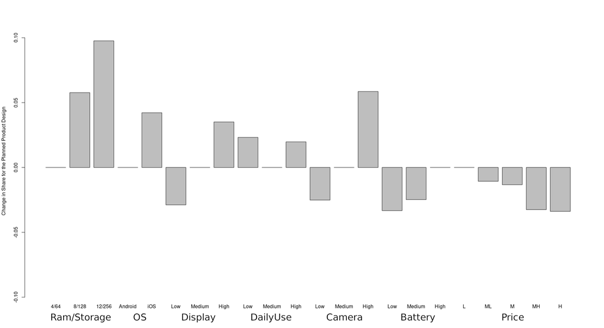

Sensitivity plot

```r
base.data <- new.data[1,]
competitor.data <- new.data[-1,]
(tradeoff <- sensitivity.mnl(fmnl.no.intercept.ranges, attributes, base.data, competitor.data))

barplot(tradeoff$increase, horiz=FALSE, names.arg=tradeoff$level,
        ylab="Change in Share for the Planned Product Design",
        ylim=c(-0.1,0.11))
grid(nx=NA, ny=NULL)
```

## Control for customers’ heterogeneity

Let’s fit a MMNL model in order to check for customers’ heterogeneity

```r
model.random.parameters <- rep("n", length=length(fmnl.no.intercept.ranges$coef))
names(model.random.parameters) <- names(fmnl.no.intercept.ranges$coef)
```

```r
m.mixed <- mlogit(choice ~ price + ram.storage + os + display +
                     dailyuse + camera + battery | -1, data = updated.smartphones.mlogit,
                  panel=TRUE, rpar = model.random.parameters, correlation = FALSE)
summary(m.mixed)
```

```
##
## Call:
## mlogit(formula = choice ~ price + ram.storage + os + display +
##     dailyuse + camera + battery | -1, data = updated.smartphones.mlogit,
##     rpar = model.random.parameters, correlation = FALSE, panel = TRUE)
##
## Frequencies of alternatives:choice
##       1       2       3
## 0.37756 0.36062 0.26182
##
## bfgs method
## 33 iterations, 0h:0m:6s
## g'(-H)^-1g = 1.3E-07
## gradient close to zero
##
## Coefficients :
##                        Estimate Std. Error  z-value  Pr(>|z|)
## priceML              -0.9115559  0.3134380  -2.9082 0.0036346 **
## priceM               -0.9674814  0.2586484  -3.7405 0.0001836 ***
## priceMH              -3.9237692  0.3542858 -11.0752 < 2.2e-16 ***
## priceH               -6.0395865  0.6874379  -8.7856 < 2.2e-16 ***
## ram.storage8/128      2.3044723  0.4182572   5.5097 3.594e-08 ***
## ram.storage12/256     2.8361625  0.4656041   6.0914 1.120e-09 ***
## osiOS                 1.7190106  0.3903689   4.4036 1.065e-05 ***
## displayMedium         1.7334951  0.3475493   4.9878 6.108e-07 ***
## displayHigh           2.8477157  0.3894030   7.3130 2.611e-13 ***
## dailyuseMedium       -0.2836613  0.5448961  -0.5206 0.6026603
## dailyuseHigh          0.0363576  0.6419763   0.0566 0.9548369
## cameraMedium          1.7542944  0.3001684   5.8444 5.085e-09 ***
## cameraHigh            3.2651353  0.3611746   9.0403 < 2.2e-16 ***
## batteryMedium         2.1840627  0.3062571   7.1315 9.930e-13 ***
## batteryHigh           3.6540828  0.3390896  10.7762 < 2.2e-16 ***
## sd.priceML            0.0071216  0.2270713   0.0314 0.9749803
## sd.priceM            -0.2212971  0.1565484  -1.4136 0.1574787
## sd.priceMH            0.7258743  0.1897105   3.8262 0.0001301 ***
## sd.priceH             2.0965535  0.5566540   3.7663 0.0001657 ***
## sd.ram.storage8/128   0.9084671  0.1824779   4.9785 6.408e-07 ***
## sd.ram.storage12/256  1.1439137  0.2055312   5.5656 2.612e-08 ***
## sd.osiOS              3.5308054  0.5654061   6.2447 4.245e-10 ***
## sd.displayMedium     -0.2930444  0.1864581  -1.5716 0.1160348
```

[output cut: 14 more lines]

```
## priceML           -Inf -0.9163593 -0.91155592 -0.91155592 -0.9067525  Inf
## priceM            -Inf -1.1167440 -0.96748136 -0.96748136 -0.8182187  Inf
## priceMH           -Inf -4.4133639 -3.92376920 -3.92376920 -3.4341745  Inf
## priceH            -Inf -7.4536904 -6.03958648 -6.03958648 -4.6254826  Inf
## ram.storage8/128  -Inf  1.6917206  2.30447232  2.30447232  2.9172240  Inf
## ram.storage12/256 -Inf  2.0646044  2.83616248  2.83616248  3.6077206  Inf
## osiOS             -Inf -0.6624814  1.71901065  1.71901065  4.1005027  Inf
## displayMedium     -Inf  1.5358396  1.73349507  1.73349507  1.9311505  Inf
## displayHigh       -Inf  2.2370962  2.84771574  2.84771574  3.4583353  Inf
## dailyuseMedium    -Inf -0.2856076 -0.28366133 -0.28366133 -0.2817150  Inf
## dailyuseHigh      -Inf -0.5739887  0.03635755  0.03635755  0.6467038  Inf
## cameraMedium      -Inf  1.2232436  1.75429439  1.75429439  2.2853452  Inf
## cameraHigh        -Inf  2.7707352  3.26513531  3.26513531  3.7595354  Inf
## batteryMedium     -Inf  2.0947938  2.18406273  2.18406273  2.2733317  Inf
## batteryHigh       -Inf  3.1801034  3.65408275  3.65408275  4.1280621  Inf
```

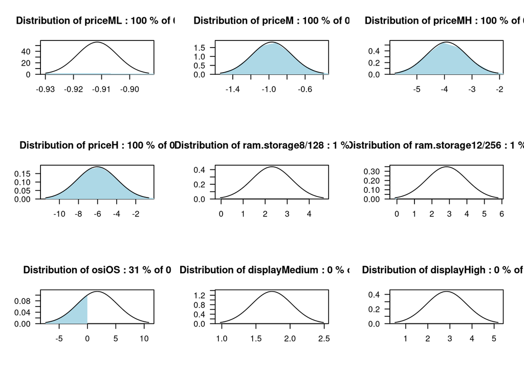

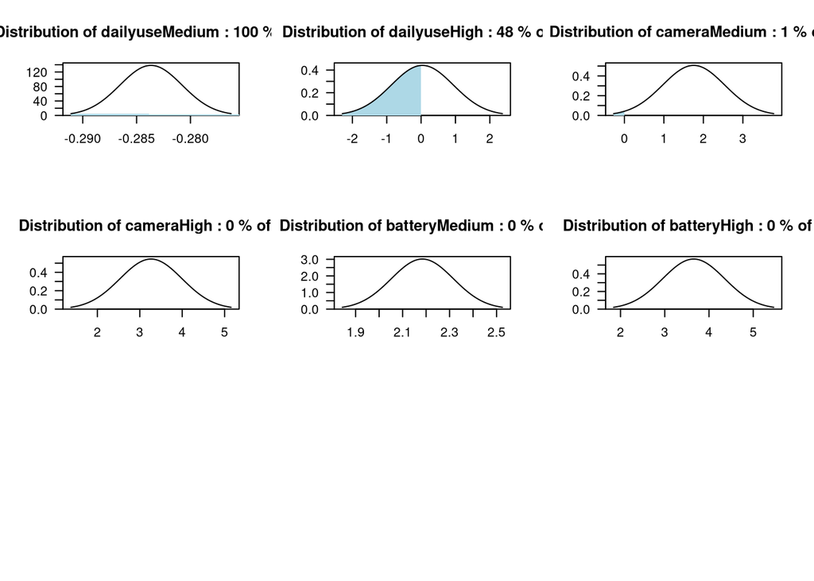

```r
plot(m.mixed)
```

The mixed mnl model mostly confirmed the previous results, but it stressed the importance of the iOS operating system (***).

From this plot we can understand that most of the people are interested into iOS as operating system and that therefore it should be taken into consideration when making managerial choices.

On the other hand, the only other variable that shows heterogeneity is the high daily usage but in every model we tested it has no statistical importance to determine the choice.

We can add correlation among variables to the model

```r
m.mixed.cor <- update(m.mixed, correlation = TRUE)
summary(m.mixed.cor)

cov2cor(cov.mlogit(m.mixed.cor))

summary(vcov(m.mixed.cor, what = "rpar", type = "cor"))
```

And then restrict to have correlation only among few of them

```r
m.mixed.cor.reduced <- update(m.mixed.cor, correlation = c("ram.storage12/256", "osiOS",
                                             "displayHigh", "batteryMedium", "batteryHigh", "cameraHigh"))
```

With the likelihood ration test we can compare these models

```r
lrtest(fmnl.no.intercept.ranges, m.mixed) #Fixed effects vs. uncorrelated random effects
```

```
## Likelihood ratio test
##
## Model 1: choice ~ price + ram.storage + os + display + dailyuse + camera +
##     battery | -1
## Model 2: choice ~ price + ram.storage + os + display + dailyuse + camera +
##     battery | -1
##   #Df   LogLik Df  Chisq Pr(>Chisq)
## 1  15 -1022.36
## 2  30  -914.87 15 214.98  < 2.2e-16 ***
## ---
## Signif. codes:  0 '***' 0.001 '**' 0.01 '*' 0.05 '.' 0.1 ' ' 1
```

```r
lrtest(m.mixed, m.mixed.cor) #Uncorrelated random effects vs. all correlated random effects
```

```
## Likelihood ratio test
##
## Model 1: choice ~ price + ram.storage + os + display + dailyuse + camera +
##     battery | -1
## Model 2: choice ~ price + ram.storage + os + display + dailyuse + camera +
##     battery | -1
##   #Df  LogLik  Df  Chisq Pr(>Chisq)
## 1  30 -914.87
## 2 135 -718.69 105 392.37  < 2.2e-16 ***
## ---
## Signif. codes:  0 '***' 0.001 '**' 0.01 '*' 0.05 '.' 0.1 ' ' 1
```

```r
lrtest(m.mixed.cor.reduced, m.mixed.cor) #partially correlated random effects vs. all correlated random effects
```

```
## Likelihood ratio test
##
## Model 1: choice ~ price + ram.storage + os + display + dailyuse + camera +
##     battery | -1
## Model 2: choice ~ price + ram.storage + os + display + dailyuse + camera +
##     battery | -1
##   #Df  LogLik Df  Chisq Pr(>Chisq)
## 1  45 -893.16
## 2 135 -718.69 90 348.94  < 2.2e-16 ***
## ---
## Signif. codes:  0 '***' 0.001 '**' 0.01 '*' 0.05 '.' 0.1 ' ' 1
```

We can now compute preference share in the MMNL model

```r
predict.mixed.mnl(m.mixed.cor, data=new.data)
```

```
##      colMeans(shares) ram.storage      os display dailyuse camera battery price
## 403       0.040025624        4/64 Android  Medium   Medium Medium    High     L
## 223       0.037019713        4/64 Android  Medium      Low Medium  Medium     L
## 878       0.060834894       8/128 Android    High      Low Medium    High    ML
## 914       0.345408368       8/128 Android    High     High Medium    High    ML
## 1400      0.094426930       8/128 Android    High     High Medium    High     M
## 1382      0.061327321       8/128 Android    High   Medium Medium    High     M
## 1887      0.118870141      12/256 Android    High     High Medium    High    MH
## 1779      0.043327346      12/256 Android    High     High   High  Medium    MH
## 1763      0.090127124       8/128     iOS    High   Medium   High  Medium    MH
## 2267      0.049604216       8/128     iOS    High     High   High  Medium     H
## 2250      0.053472928      12/256     iOS    High   Medium   High  Medium     H
## 2264      0.005555394       8/128 Android    High     High   High  Medium     H
```

And compute confidence intervals

```r
BootCI.predict.mixed.mnl(m.mixed.cor, data=new.data, nresp = 3, nsim = 3)
```

```
##             share         2.5%        97.5% ram.storage      os display
## 403  3.532314e-02 8.460631e-08 7.381572e-06        4/64 Android  Medium
## 223  2.219751e-07 3.048091e-16 2.026678e-13        4/64 Android  Medium
## 878  3.541265e-06 3.805690e-13 2.957207e-08       8/128 Android    High
## 914  2.968455e-01 3.128272e-03 3.894825e-01       8/128 Android    High
## 1400 2.372691e-03 7.018662e-05 3.017173e-03       8/128 Android    High
## 1382 3.049474e-03 1.284385e-02 3.276124e-01       8/128 Android    High
## 1887 4.892319e-03 9.048391e-09 3.832849e-01      12/256 Android    High
## 1779 1.856822e-01 6.186683e-09 2.395371e-01      12/256 Android    High
## 1763 3.397528e-01 2.631843e-04 5.744157e-01       8/128     iOS    High
## 2267 1.319145e-02 4.010653e-06 1.034991e-01       8/128     iOS    High
## 2250 1.168326e-01 1.119199e-02 3.381246e-01      12/256     iOS    High
## 2264 2.054124e-03 1.167660e-15 3.843072e-05       8/128 Android    High
##      dailyuse camera battery price
## 403    Medium Medium    High     L
## 223       Low Medium  Medium     L
## 878       Low Medium    High    ML
## 914      High Medium    High    ML
## 1400     High Medium    High     M
## 1382   Medium Medium    High     M
## 1887     High Medium    High    MH
## 1779     High   High  Medium    MH
## 1763   Medium   High  Medium    MH
## 2267     High   High  Medium     H
## 2250   Medium   High  Medium     H
## 2264     High   High  Medium     H
```

Obviously, confidence intervals ended up to be pretty big, but the preference shares were realistic: the preferred smartphone was defined as an Android based smartphone with a Medium-Low price range, 8GB of RAM and 128 of storage, with a medium camera level and high levels of battery, display and daily use. This profile, among all the others, would retain a 35% user’s preference share.

# Conclusions

Results showed and confirmed some of our prior beliefs, in particular we understood that the most prominent price sector is the medium to medium-low, where most of the preference is located.

From the willingness-to-pay we got that people are going to pay up to 200 more euros in order to buy a smartphone equipped with iOS as operating system. Given that the OS is the only “non-physical” property that we included in the survey we think some considerations should be made.

We know that from a technological point of view the advantages of iOS is the optimization made between software and hardware and the easiness to use that some part of users seek. So the reasons behind these choice has not to be thought as a “hard” choice but more of a “soft” one, where the brand makes a great difference.

## Managerial advices

From a managerial point of view our results suggest that the range where investments should be made is the medium to medium-low, and particular attention should be put into the quality/price ratio, with an eye on a good amount of RAM and storage, and good display and battery.

On the other hand, if one wants to enter the high-end market he/she has to consider the predominant share that iOS has in that range.

### References

[1] Taherdoost, Hamed. (2016). Sampling Methods in Research Methodology; How to Choose a Sampling Technique for Research. International Journal of Academic Research in Management. 5. 18-27. 10.2139/ssrn.3205035.

[2] Galeazzi Andrea, https://andreagaleazzi.com/

[3] pandas - Python Data Analysis Library, https://pandas.pydata.org

[4] Tidy data, Hadley Wickham; *The Journal of Statistical Software*, vol. 59, 2014.